# Introduction

# EXERCISE 4: DataFrames

1. Create a new variable/column called `bmi` containing the bmi of the respondents. $$BMI = kg/m^2$$
   - (power of 2 in R is written with `**2` or `^2`)
2. What is the lowest bmi? Use either `summary()` or `min()`

## Bonus exercise

1. Look up the help file for the function `which.min` and `which.max`
2. Using the functions above, can you determine how many cigarettes (`cgtsday`) the person with the lowest bmi smokes per day? (think how logicals work when subsetting)

# Saving files

Check your directory with `getwd`. Directory can be changed with `setwd`.

We can save a .csv-file (comma-separated values) with `write.table`:

```r
write.table(ess2014_df, file = "my_ess2014dk.csv", sep = ",", col.names = TRUE)
```

**Code breakdown:**

[output not shown]

A .csv-file is a multi-platform format and can be loaded by most statistical software (Excel, STATA, etc.).

## Reading files

Make sure you are in the right working directory (`getwd`)

```r
my_ess2014dk <- read.table(file = "my_ess2014dk.csv", header = TRUE, sep = ",")
```

**Code breakdown:**

[output not shown]

# R Libraries - Packages

R being open source means that a lot of developers are constantly adding new functions to R. These new functions are distributed as *R packages* that can be loaded into the R library.

All the commands you have been using so far have been part of the `base` package (ships with R).

Packages are installed using (name of package *with* quotes!):

`install.packages('packagename')`

The functions from the package is loaded into the environment using (name of package *without* quotes!):

`library(packagename)`

Information for installed packages can be found using (name of package *with* quotes!):

`library(help = 'packagename')`

# Reading files with `xlsx`

Data files come in a variety of formats. Various packages have been developed and are widely used for reading different data formats into R: .csv, .xlsx (Excel), .dta (Stata), .sas7bdat (SAS), .sav (SPSS) and so on.

Some very useful packages for reading data includes:

- `readr` (for reading and writing .csv and text file formats - faster than the base functions)
- `haven` (for reading and writing Stata, SPSS and SAS files)
- `xlsx` (for reading and writing excel files)

In the following we will take a closer look at `xlsx`.

Start by installing the package and loading it into R.

The `library()` function loads packages into R. Packages have to be loaded into R before use. All functions installed are not just immmediately available as that would make R slower and could easily result in conflicts between packages and functions (functions with the same name etc.)

Notice that the package name must have quote around it when installing (`install.packages('xlsx')` but not when loading it (`library(xlsx)`).

```
install.packages('xlsx')
library(xlsx)
```

## Working directories

Earlier we imported a data set from a URL but what about from the local file system?

Unlike a URL, file locations on a local file system (i.e. your personal computer) is not fixed. R has to be told where data is located in order to be able to import it.

It is both possible to specify the full path to your file, when importing.

Alternatively, you can change R's working directory. The working directory is the location in which R is looking for files. Using working directories is recommended - especially when sharing scripts. That way only the working directory has to be changed instead of all the file paths.

Check the current working directory with `getwd()`:

```r
getwd() # prints the current working directory
```

'D:/OneDrive - Aalborg Universitet/CALDISS/Aktiviteter/workshops_repos/workshop_r-intro/notebooks'

`getwd()` tells me that my working directory is in the folder "notebooks". This is not the folder where I keep my data!

The working directory can be changed using `setwd()` and inputting the desired file path:

```r
setwd('D:/OneDrive - Aalborg Universitet/CALDISS/Aktiviteter/workshops_repos/workshop_r-intro/data')
```

We can confirm that the directory is changed by calling `getwd()` again:

```r
getwd()
```

'D:/OneDrive - Aalborg Universitet/CALDISS/Aktiviteter/workshops_repos/workshop_r-intro/data'

File paths can often be a cause of problems as it is easy to make errors. Instead of filling in the working directory manually, the working directory can be set using RStudio.

Go to "Session" > "Set Working Directory" > "Choose Directory":

[figure not shown]

When set R will execute the `setwd()` command for that directory from the console. That line of code can then be copied into your script:

[figure not shown]

## Reading (xlsx) files

With the working directory sorted out we are ready to import the data.

We are importing an xlsx file using the `xlsx` package but import functions work similarly regardless of packages (i.e. the working directory has to be set for where the data is located).

`read.xlsx()` imports an xlsx file. The file has to be assigned an object (otherwise the data is just printed in the console).

Remember that an excel file consists of several sheets so `read.xlsx()` expects an arguement for what sheet to import (here we are importing the first sheet (`sheetIndex = 1`) as the file only contains one sheet).

```r
mtcars <- read.xlsx("mtcars.xlsx", sheetIndex = 1)
```

The data is now loaded into R as a data frame:

```r
head(mtcars)
```

| NA. | mpg | cyl | disp | hp | drat | wt | qsec | vs | am | gear | carb |
| --- | --- | --- | --- | --- | --- | --- | --- | --- | --- | --- | --- |
| Mazda RX4 | 21.0 | 6 | 160 | 110 | 3.90 | 2.620 | 16.46 | 0 | 1 | 4 | 4 |
| Mazda RX4 Wag | 21.0 | 6 | 160 | 110 | 3.90 | 2.875 | 17.02 | 0 | 1 | 4 | 4 |
| Datsun 710 | 22.8 | 4 | 108 | 93 | 3.85 | 2.320 | 18.61 | 1 | 1 | 4 | 1 |
| Hornet 4 Drive | 21.4 | 6 | 258 | 110 | 3.08 | 3.215 | 19.44 | 1 | 0 | 3 | 1 |
| Hornet Sportabout | 18.7 | 8 | 360 | 175 | 3.15 | 3.440 | 17.02 | 0 | 0 | 3 | 2 |
| Valiant | 18.1 | 6 | 225 | 105 | 2.76 | 3.460 | 20.22 | 1 | 0 | 3 | 1 |

# EXERCISE 7: Writing an excel file

You have previously worked with the ESS data set. You should still have the data frame `ess2014_df` (or whatever name you gave it) in your environment.

1. Look at the help file for `write.xlsx()` (`?write.xlsx`). Pay special attention to the default state of the arguements `col.names` and `row.names`.
2. Save the data frame `ess2014_df` as an excel file *withot* storing the row names.

# Visuazliation in R - `ggplot2`

`ggplot2` is a package for creating plots and visuazliation. Histograms, scatterplots, lineplots and so on.

```r
library(ggplot2)
```

`ggplot()` works in "layers". This allows one to combine several graphs into one plot.

The basic syntax for `ggplot()` is as follows:

- Define the parameters of your plot: data and aesthetics (x-axis, y-axis and colouring options)
- Add a graph layer
- (add more graph layers)
- Set settings for your plot (theme, tick marks and so on)

`ggplot2` is incredibly versatile and has a huge amount of functions. Here we will just try out a simple visualization using default settings.

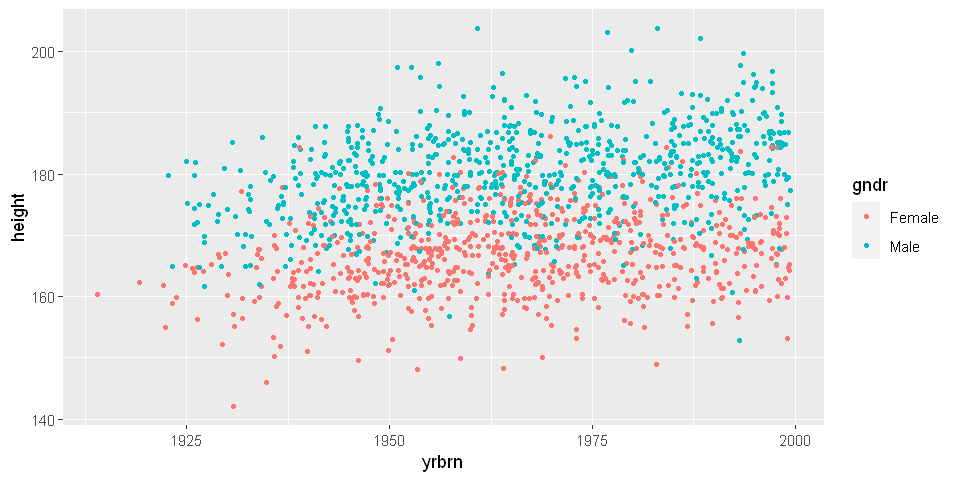

```r
ggplot(data = ess2014_df, aes(x = yrbrn, y = height, colour = gndr)) +
    geom_point(size = 1, position = "jitter")
```

**Code breakdown:**

[output not shown]

# EXERCISE 7: `ggplot2`

1. Install the package `ggplot2` and load it.
2. Create a histogram of the variable `yrbrn` in the ESS2014DK data with `ggplot` and `geom_histogram()` (one variable, so only x needs to be specified. No colour)
3. Create a scatterplot of `yrbrn` and `cgtsday` using `geom_point`. (use arguement `position = "jitter"` to make it nicer).

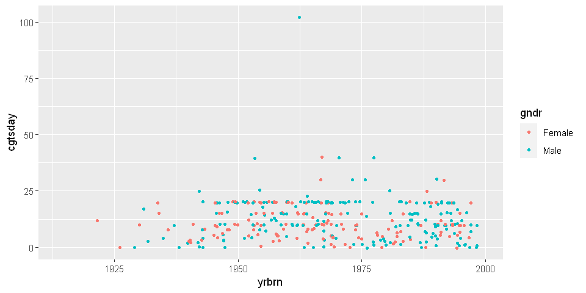

```r
ggplot(data = ess2014_df, aes(x = yrbrn, y = cgtsday, colour = gndr)) +
    geom_point(size = 1, position = "jitter")
```

# Summation

R objects are created using the operator `<-`. R objects can be pretty much anything.

Objects are assigned a `class`. The class can be checked with `class(object)`. Classes can be coerced with commands like `as.numeric()` or `as.character()`

Vectors are groupings of values. They are created with `c()`. Vectors can be subset using `[]`.

Data frames are R's version of a spreadsheet (rows and columns). A column/variable can be selected using `$`. A column/variable can (in most cases) be treated like a vector.

Data frames can be subset using `[ , ]` or `$`. Rows are specified before the comma, and columns after the comma.

Other functions can be loaded into R via packages.

The package `xlsx` can be used for reading and writing excel files.

The package `ggplot2` can be used for visualizations.